# RBIF111 - Homework 9

Neshita Kipuw

2024-12-10

```r
# Load necessary packages
library(ggplot2)
library(tidyr)
library(dplyr)
library(stats)
library(DESeq2)
library(reshape2)
library(data.table)
library(tibble)
library(plotly)
library(scatterplot3d)
```

# 1 Question 1

## 1.1 Description of PCA analysis

Principal Component Analysis (PCA) is a powerful statistical technique used to simplify complex, high-dimensional data sets by identifying the most important patterns and reducing data complexity, while preserving as much of the original information as possible. How it works:  
1. Data Transformation: at its core, PCA is about transforming the original data set into a new coordinate system. Imagine there is a cloud of data points in a multidimensional space. PCA finds the directions (principal components) along which the data varies the most.  
2. Variance Maximization: the first principal component is the direction that explains the largest amount of variance in the data. This is like finding the “best-fit line” that captures the most spread-out variation, but in multiple dimensions. The second principal component is orthogonal (i.e., perpendicular) to the first and captures the next most important pattern of variation.  
3. Dimensionality Reduction: by ranking these principal components by the amount of variance they explain, it can decide how many components to keep. For example, it is possible that just two or three components capture 80-90% of the total variation in the original data set.

Mathematically, PCA uses *eigenvalue* decomposition of the data’s covariance matrix. Therefore, each principal component is an *eigenvector*. The corresponding *eigenvalue* represents how much variance that component explains. Some of the advantages are reduced data complexity, helps to identify hidden patterns, useful for visualization, and it is the pre-processing step for many machine learning algorithms.

References: [1] Jolliffe, I. T. (2002). Principal Component Analysis (2nd ed.). Springer. [2] Lever, J., Krzywinski, M., & Altman, N. (2017). Principal component analysis. Nature Methods, 14(7), 641-642.

# 2 Question 2

## 2.1 PCA analysis

### 2.1.1 Non-normalized data set

The data set obtained from GEO is a study to investigate how lemafulin (as part of a combination therapy strategy) overcomes the sorafenib resistance in hepatocellular carcinoma (HCC). The data set is a RNA-seq on the HepG2 cells treated with DMSO (Control) or lemafulin (Tx).

The (hidden) code below will download the data set as-is from GEO, i.e., not normalized.

```r
#GEO download
GEODataDownload <- function(DS, gpl, gsm, PlateAnnotInfo, GenerateMetaData, Technology){
  library(DESeq2); library(data.table)
  if(Technology == "Array"){
    gset <- getGEO(DS)
    if(length(gset) > 1) idx <- grep(gpl, attr(gset, "names")) else idx <- 1
    gset <- gset[[idx]]
    fvarLabels(gset) <- make.names(fvarLabels(gset))
    comp <- gsub(" ", "", gsm)
    comp <- gsub(",", "", comp)
    gsms <- paste0(comp)
    #### Set up raw names ####
    sml <- c()
    for(i in 1:nchar(gsms)){ sml[i] <- substr(gsms,i,i)}
    ex <- exprs(gset)
    qx <- as.numeric(quantile(ex, c(0., 0.25, 0.5, 0.75, 0.99, 1.0), na.rm=T))
    LogC <- (qx[5] > 100) ||
      (qx[6]-qx[1] > 50 && qx[2] > 0) ||
      (qx[2] > 0 && qx[2] < 1 && qx[4] < 2)
    if(LogC){ ex[which(ex <= 0)] <- NaN
    exprs(gset) <- log2(ex) }
    sml <- paste("G", sml, sep="")
    f1 <- as.factor(sml)
    gset$description2 <- f1
    design <- model.matrix(~description2 + 0, gset)
    colnames(design) <- levels(f1)
    fit <- lmFit(gset, design)
    cont.matrix <- makeContrasts(G1-G0, levels = design)
    fit2 <- contrasts.fit(fit, cont.matrix)
    fit2 <- eBayes(fit2, 0.01)
    tT <- topTable(fit2, adjust="fdr", sort.by = "B", number = 25000000000)
    #### subset ####
    ex2 <- data.table(subset(tT, select=c("ID", "logFC", "P.Value", "adj.P.Val")))
    ex2$ID <- as.character(ex2$ID)
    #### annotate with gene names ####
    plat <- PlateAnnotInfo[GPLID == gpl,][,!"GPLID", with = FALSE]
    if(nrow(plat) == 0){ print(paste("There is no annotation information available for", gpl)) }
    plat$ID <- as.character(plat$ID)
    plat <- plat[!duplicated(plat$ID),]
    ex2 <- merge(plat, ex2, by = "ID")
    ex2$ID <- as.character(ex2$ID)
    exraw <- data.table(ex)
    exraw$ID <- as.character(rownames(ex))
    #### annotate raw data with gene names ####
    ex2 <- merge(ex2, exraw, by = "ID")
    #### Generate Meta Data ####
    Pdat <- pData(gset)
    #### Add Meta data ####
    Pdat <- as.data.table(Pdat)
    return(list(Data = ex2, MetaData = Pdat))
  }

  if(Technology == "RNAseq"){
    ACC <- paste("acc=", DS, sep = "")
    file <- paste("file=", DS, "_raw_counts_GRCh38.p13_NCBI.tsv.gz", sep = "")
    comp <- gsub(" ", "", gsm)
    comp <- gsub(",", "", comp)
    gsms <- paste0(comp)
    #### Set up DEG names ####
    urld <- "https://www.ncbi.nlm.nih.gov/geo/download/?format=file&type=rnaseq_counts"
    path <- paste(urld, ACC, file, sep="&");
    tbl <- as.matrix(data.table::fread(path, header=T, colClasses="integer"), rownames="GeneID")
    exraw <- tbl
    apath <- paste(urld, "type=rnaseq_counts", "file=Human.GRCh38.p13.annot.tsv.gz", sep="&")
    annot <- data.table::fread(apath, header=T, quote="", stringsAsFactors=F, data.table=F)
    rownames(annot) <- annot$GeneID
    sml <- strsplit(gsms, split="")[[1]]
    sel <- which(sml != "X")
    sml <- sml[sel]
    tbl <- tbl[ ,sel]
    gs <- factor(sml)
    groups <- make.names(c("Ctrl", "Tx"))
    levels(gs) <- groups
    sample_info <- data.frame(Group = gs, row.names = colnames(tbl))
    keep <- rowSums( tbl >= 10 ) >= min(table(gs))
    tbl <- tbl[keep, ]
    ds <- DESeqDataSetFromMatrix(countData=tbl, colData=sample_info, design= ~Group)
    ds <- DESeq(ds, test="Wald", sfType="poscount")
    r <- results(ds, contrast=c("Group", groups[2], groups[1]), alpha=0.05, pAdjustMethod ="fdr")
    tT <- r[order(r$padj)[1:length(r$padj)],]
    tT <- merge(as.data.frame(tT), annot, by=0, sort=F)
    tT <- subset(tT, select=c("GeneID","padj","pvalue","lfcSE","stat","log2FoldChange","baseMean","Symbol","Description"))
    #### subset ####
    ex2 <- data.table(subset(tT, select=c("GeneID", "Symbol", "Description", "log2FoldChange", "pvalue", "padj")))
    #### Adjust column names ####
    setnames(ex2, c("GeneID", "Symbol", "Description"), c("ENTREZID", "SYMBOL", "GENENAME"))
    #### Get Raw data ####
    GeneID <- as.integer(rownames(exraw))
    exraw <- as.data.table(exraw)
    #### Update column names ####
    exraw$ENTREZID <- GeneID
    #### merge FC and raw data together ####
    mer <- merge(ex2, exraw, by = "ENTREZID")
    return(mer)  }
}

# Execute the GEODataDownload function and obtain the RNAseq data set
RNAseqData <- GEODataDownload(DS = "GSE252988",
                              gpl = "GPL24676",
                              gsm = "000111",
                              PlateAnnotInfo = "Only needed if the data was generated using MicroArrays",
                              GenerateMetaData = "Only needed if the data was generated using MicroArrays",
                              Technology = "RNAseq")

# Save the RNAseq data set to the working directory
saveRDS(RNAseqData, file = "./RNAseq_GSE252988.rds")

# Reload the file into R environment
GSE252988 <- readRDS("./RNAseq_GSE252988.rds")
head(GSE252988)
```

```
## Key: <ENTREZID>
##    ENTREZID   SYMBOL                                GENENAME log2FoldChange
##       <int>   <char>                                  <char>          <num>
## 1:        1     A1BG                  alpha-1-B glycoprotein    -0.05902420
## 2:        2      A2M                   alpha-2-macroglobulin     0.50122198
## 3:        9     NAT1                   N-acetyltransferase 1     0.02029019
## 4:       12 SERPINA3                serpin family A member 3    -0.33537741
## 5:       13    AADAC               arylacetamide deacetylase    -0.40990950
## 6:       14     AAMP angio associated migratory cell protein    -0.21600496
##          pvalue         padj GSM8011934 GSM8011935 GSM8011936 GSM8011937
##           <num>        <num>      <int>      <int>      <int>      <int>
## 1: 9.363305e-01 9.746090e-01        116        109        334        115
## 2: 1.256982e-06 3.607809e-05      40728      35346      41879      55588
## 3: 9.226150e-01 9.681858e-01        116        109        107        101
## 4: 1.845143e-02 8.126032e-02       8170       7200       4820       5726
## 5: 4.756960e-01           NA         17         10         26          9
## 6: 5.845819e-03 3.439402e-02       5586       4772       4301       4044
##    GSM8011938 GSM8011939
##         <int>      <int>
## 1:        298        111
## 2:      51201      51082
## 3:        119         97
## 4:       4004       5167
## 5:         18         11
## 6:       3977       3806
```

The code below will convert the data into long format to add the sample annotation of “Ctrl” and “Tx.” Then the variance for each gene is calculated and sorted in descending order to obtain the top 100 and top 1000 genes. Finally, the data will be converted back into wide format in preparation for PCA analysis.

```r
# Get gene expressions from a control and a treatment sample
GSE252988_2 <- as.data.frame(GSE252988[, c(2, 7:12)])
head(GSE252988_2)
```

```
##     SYMBOL GSM8011934 GSM8011935 GSM8011936 GSM8011937 GSM8011938 GSM8011939
## 1     A1BG        116        109        334        115        298        111
## 2      A2M      40728      35346      41879      55588      51201      51082
## 3     NAT1        116        109        107        101        119         97
## 4 SERPINA3       8170       7200       4820       5726       4004       5167
## 5    AADAC         17         10         26          9         18         11
## 6     AAMP       5586       4772       4301       4044       3977       3806
```

```r
# Convert to long format to add annotation
new_df <- data.frame(
  Sample_ID = c("GSM8011934","GSM8011935", "GSM8011936", "GSM8011937", "GSM8011938", "GSM8011939"),
  group = c("Ctrl", "Ctrl", "Ctrl", "Tx", "Tx", "Tx")
)

GSE252988_3 <- reshape2::melt(GSE252988_2, id.vars = c("SYMBOL"), variable.name = "Sample_ID", value.name = "Expression")

# merge with sample annotation
GSE252988_4 <- as.data.frame(merge(GSE252988_3, new_df, by = "Sample_ID"))
head(GSE252988_4)
```

```
##    Sample_ID   SYMBOL Expression group
## 1 GSM8011934     A1BG        116  Ctrl
## 2 GSM8011934      A2M      40728  Ctrl
## 3 GSM8011934     NAT1        116  Ctrl
## 4 GSM8011934 SERPINA3       8170  Ctrl
## 5 GSM8011934    AADAC         17  Ctrl
## 6 GSM8011934     AAMP       5586  Ctrl
```

```r
# Calculate variance for each gene
GSE252988_5 <- GSE252988_4 %>%
  group_by(SYMBOL) %>%
  summarize(Variance = var(Expression), .groups = "drop")
head(GSE252988_5)
```

```
## # A tibble: 6 × 2
##   SYMBOL    Variance
##   <chr>        <dbl>
## 1 A1BG        11152.
## 2 A1BG-AS1     2273.
## 3 A1CF        29562.
## 4 A2M      60617209.
## 5 A2M-AS1      6410.
## 6 AAAS       234705.
```

```r
# Get top 100 & 1000 genes with greatest variance
top100 <- GSE252988_5 %>% arrange(desc(Variance)) %>% head(100)  # get top 100 by variance
top1000 <- GSE252988_5 %>% arrange(desc(Variance)) %>% head(1000)  # get top 1000 by variance

# Get data for top 100 & 1000 genes
top100_data <- GSE252988_4 %>% filter(SYMBOL %in% top100$SYMBOL) # get expression values
head(top100_data)
```

```
##    Sample_ID SYMBOL Expression group
## 1 GSM8011934    A2M      40728  Ctrl
## 2 GSM8011934  ACAT2       2347  Ctrl
## 3 GSM8011934   ACLY      11113  Ctrl
## 4 GSM8011934   ACTB     113497  Ctrl
## 5 GSM8011934  ACTG1     112531  Ctrl
## 6 GSM8011934    AFP      20585  Ctrl
```

```r
top1000_data <- GSE252988_4 %>% filter(SYMBOL %in% top1000$SYMBOL) # get expression values
tail(top1000_data)
```

```
##       Sample_ID       SYMBOL Expression group
## 5995 GSM8011939     RNA18SN3      16280    Tx
## 5996 GSM8011939     RNA28SN3       4284    Tx
## 5997 GSM8011939 LOC112268430       3073    Tx
## 5998 GSM8011939 LOC112694756      19400    Tx
## 5999 GSM8011939      MIR9898       5760    Tx
## 6000 GSM8011939     MIR10394       4596    Tx
```

```r
# Function to convert back to wide format
data_wide <- function(data) {
  data %>%
    select(-group) %>%  # Remove group column before pivoting
    pivot_wider(names_from = SYMBOL, values_from = Expression) %>%
    column_to_rownames(var = "Sample_ID") %>%  # Convert sample IDs to row names
    as.data.frame()  # Output as a data frame
}

# Execute the wide format function
top100_df <- data_wide(top100_data)
top1000_df <- data_wide(top1000_data)
```

The code below will perform the PCA analysis.

```r
# Get the group annotation to add into PCA analysis
group_annotate <- GSE252988_4 %>% distinct(Sample_ID, group) %>% pull(group)

# Function for PCA analysis
my_pca <- function(data, annotation) {
  pca_result <- prcomp(data, scale. = TRUE)

  # explain variance
  var_explained <- summary(pca_result)$importance[2, ]
  cumulative_var <- cumsum(var_explained)

  # get the number of PCs that explain 75% of the variance
  num_pcs <- which(cumulative_var >= 0.75)[1]

  # get scores and annotation
  pca_scores <- as.data.frame(pca_result$x)
  pca_scores$Group <- annotation

  return(list(
    pca_result = pca_result,
    pca_scores = pca_scores,
    num_pcs = num_pcs,
    cumulative_variance = cumulative_var
  ))
}

# Execute PCA analysis function
top100_pca <- my_pca(top100_df, group_annotate)
top1000_pca <- my_pca(top1000_df, group_annotate)
```

The (hidden) code below will visualize the results of PCA analysis on the top 100 and top 1000 genes using a 3D graph.

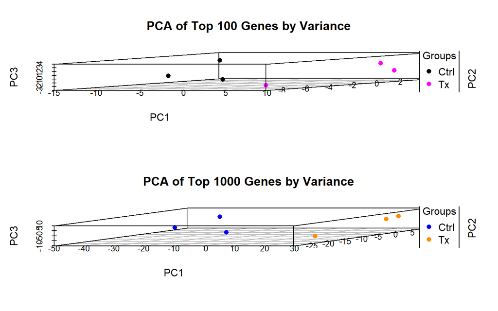

```r
## Visualize PCA results
# Function to create 3D PCA plots
plot_pca_3d <- function(pca_scores, title, colors) {
  # Create the 3D scatter plot
  s3d <- scatterplot3d(
    pca_scores$PC1,
    pca_scores$PC2,
    pca_scores$PC3,
    color = colors[as.factor(pca_scores$Group)],
    pch = 16,
    main = title,
    xlab = "PC1",
    ylab = "PC2",
    zlab = "PC3",
    angle = 40,  # Rotation angle
    box = TRUE
  )

  # Add legend
  legend("right",
         legend = levels(as.factor(pca_scores$Group)),
         col = colors,
         pch = 16,
         title = "Groups")
}

# Set up plotting layout
par(mfrow = c(2, 1), mar = c(4, 4, 4, 4))

# Plot top 100 PCA
plot_pca_3d(
  top100_pca$pca_scores,
  "PCA of Top 100 Genes by Variance",
  c("black", "magenta")
)

# Plot top 1000 PCA
plot_pca_3d(
  top1000_pca$pca_scores,
  "PCA of Top 1000 Genes by Variance",
  c("blue", "darkorange")
)
```

```r
# Reset plotting parameters
par(mfrow = c(1, 1))
```

### 2.1.2 Normalized data set

The (hidden) code below will download the normalized data set from GEO.

```r
# Download normalized data set from GEO
GEODataDownload <- function(DS, gpl, gsm, PlateAnnotInfo, GenerateMetaData, Technology){
  library(DESeq2); library(data.table)
  if(Technology == "Array"){
    gset <- getGEO(DS)
    if(length(gset) > 1) idx <- grep(gpl, attr(gset, "names")) else idx <- 1
    gset <- gset[[idx]]
    fvarLabels(gset) <- make.names(fvarLabels(gset))
    comp <- gsub(" ", "", gsm)
    comp <- gsub(",", "", comp)
    gsms <- paste0(comp)
    #### Set up raw names ####
    sml <- c()
    for(i in 1:nchar(gsms)){ sml[i] <- substr(gsms,i,i)}
    ex <- exprs(gset)
    qx <- as.numeric(quantile(ex, c(0., 0.25, 0.5, 0.75, 0.99, 1.0), na.rm=T))
    LogC <- (qx[5] > 100) ||
      (qx[6]-qx[1] > 50 && qx[2] > 0) ||
      (qx[2] > 0 && qx[2] < 1 && qx[4] < 2)
    if(LogC){ ex[which(ex <= 0)] <- NaN
    exprs(gset) <- log2(ex) }
    sml <- paste("G", sml, sep="")
    f1 <- as.factor(sml)
    gset$description2 <- f1
    design <- model.matrix(~description2 + 0, gset)
    colnames(design) <- levels(f1)
    fit <- lmFit(gset, design)
    cont.matrix <- makeContrasts(G1-G0, levels = design)
    fit2 <- contrasts.fit(fit, cont.matrix)
    fit2 <- eBayes(fit2, 0.01)
    tT <- topTable(fit2, adjust="fdr", sort.by = "B", number = 25000000000)
    #### subset ####
    ex2 <- data.table(subset(tT, select=c("ID", "logFC", "P.Value", "adj.P.Val")))
    ex2$ID <- as.character(ex2$ID)
    #### annotate with gene names ####
    plat <- PlateAnnotInfo[GPLID == gpl,][,!"GPLID", with = FALSE]
    if(nrow(plat) == 0){ print(paste("There is no annotation information available for", gpl)) }
    plat$ID <- as.character(plat$ID)
    plat <- plat[!duplicated(plat$ID),]
    ex2 <- merge(plat, ex2, by = "ID")
    ex2$ID <- as.character(ex2$ID)
    exraw <- data.table(ex)
    exraw$ID <- as.character(rownames(ex))
    #### annotate raw data with gene names ####
    ex2 <- merge(ex2, exraw, by = "ID")
    #### Generate Meta Data ####
    Pdat <- pData(gset)
    #### Add Meta data ####
    Pdat <- as.data.table(Pdat)
    return(list(Data = ex2, MetaData = Pdat))
  }

  if(Technology == "RNAseq"){
    ACC <- paste("acc=", DS, sep = "")
    file <- paste("file=", DS, "_raw_counts_GRCh38.p13_NCBI.tsv.gz", sep = "")
    comp <- gsub(" ", "", gsm)
    comp <- gsub(",", "", comp)
    gsms <- paste0(comp)
    #### Set up DEG names ####
    urld <- "https://www.ncbi.nlm.nih.gov/geo/download/?format=file&type=rnaseq_counts"
    path <- paste(urld, ACC, file, sep="&");
    tbl <- as.matrix(data.table::fread(path, header=T, colClasses="integer"), rownames="GeneID")
    exraw <- tbl
    apath <- paste(urld, "type=rnaseq_counts", "file=Human.GRCh38.p13.annot.tsv.gz", sep="&")
    annot <- data.table::fread(apath, header=T, quote="", stringsAsFactors=F, data.table=F)
    rownames(annot) <- annot$GeneID
    sml <- strsplit(gsms, split="")[[1]]
    sel <- which(sml != "X")
    sml <- sml[sel]
    tbl <- tbl[ ,sel]
    gs <- factor(sml)
    groups <- make.names(c("Ctrl", "Tx"))
    levels(gs) <- groups
    sample_info <- data.frame(Group = gs, row.names = colnames(tbl))
    keep <- rowSums( tbl >= 10 ) >= min(table(gs))
    tbl <- tbl[keep, ]
    ds <- DESeqDataSetFromMatrix(countData=tbl, colData=sample_info, design= ~Group)

    # Estimate size factors and get normalized counts
    ds <- estimateSizeFactors(ds)
    # Continue with DESeq analysis
    ds <- DESeq(ds, test="Wald", sfType="poscount")
    normalized_counts <- counts(ds, normalized=TRUE)

    r <- results(ds, contrast=c("Group", groups[2], groups[1]), alpha=0.05, pAdjustMethod ="fdr")
    tT <- r[order(r$padj)[1:length(r$padj)],]
    tT <- merge(as.data.frame(tT), annot, by.x="row.names", by.y="GeneID", sort=F)
    tT <- subset(tT, select=c("Row.names","padj","pvalue","lfcSE","stat","log2FoldChange","baseMean","Symbol","Description"))

    #### subset ####
    ex2 <- data.table(subset(tT, select=c("Row.names", "Symbol", "Description", "log2FoldChange", "pvalue", "padj")))
    setnames(ex2, c("Row.names", "Symbol", "Description"), c("ENTREZID", "SYMBOL", "GENENAME"))

    #### Get Raw data ####
    exraw <- as.data.table(exraw)
    exraw$ENTREZID <- rownames(exraw)

    #### merge FC and raw data together ####
    mer <- merge(ex2, exraw, by = "ENTREZID")

    # Add normalized counts to the merged data
    normalized_counts_dt <- as.data.table(normalized_counts, keep.rownames = "ENTREZID")
    final_table <- merge(mer, normalized_counts_dt, by = "ENTREZID")

    return(final_table)
  }
}

# Execute the GEODataDownload function and obtain the RNAseq data set
RNAseqData2 <- GEODataDownload(DS = "GSE252988",
                              gpl = "GPL24676",
                              gsm = "000111",
                              PlateAnnotInfo = "Only needed if the data was generated using MicroArrays",
                              GenerateMetaData = "Only needed if the data was generated using MicroArrays",
                              Technology = "RNAseq")

# Save the RNAseq data set to the working directory
saveRDS(RNAseqData2, file = "./RNAseq_GSE252988_norm.rds")

# Reload the file into R environment
GSE252988_v2 <- readRDS("./RNAseq_GSE252988_norm.rds")

# Clean up the data set
colnames(GSE252988_v2) <- gsub(".y$", "", colnames(GSE252988_v2))
remove_cols <- grepl(".x$", colnames(GSE252988_v2))
GSE252988_v2.2 <- subset(GSE252988_v2, select = !remove_cols)
head(GSE252988_v2.2)
```

```
## Key: <ENTREZID>
##    ENTREZID   SYMBOL                                            GENENAME
##      <AsIs>   <char>                                              <char>
## 1:        1     A1BG                              alpha-1-B glycoprotein
## 2:      100      ADA                                 adenosine deaminase
## 3:     1000     CDH2                                          cadherin 2
## 4:    10001     MED6                          mediator complex subunit 6
## 5:    10003  NAALAD2      N-acetylated alpha-linked acidic dipeptidase 2
## 6:    10004 NAALADL1 N-acetylated alpha-linked acidic dipeptidase like 1
##    log2FoldChange      pvalue       padj GSM8011934 GSM8011935 GSM8011936
##             <num>       <num>      <num>      <num>      <num>      <num>
## 1:    -0.05894454 0.936414192 0.97458077  100.67289  107.46711   353.8666
## 2:    -0.42403073 0.006821271 0.03898181  433.93485  397.33251   345.3907
## 3:    -0.08996579 0.464315156 0.68761214 4218.71461 4224.73902  3205.9889
## 4:    -0.15250473 0.127802873 0.31151249  815.79752  805.51033   838.0493
## 5:    -0.33849182 0.007361411 0.04125057  481.66768  497.89806   441.8035
## 6:     0.45087603 0.084751650 0.23706910   86.78697   64.08589   135.6135
##    GSM8011937 GSM8011938 GSM8011939
##         <num>      <num>      <num>
## 1:   117.9966   307.6680   113.5633
## 2:   328.3383   239.5267   309.9970
## 3:  3860.0274  3171.6644  3915.3747
## 4:   740.8133   712.3856   759.1346
## 5:   363.2243   355.1603   406.1677
## 6:   130.3093   148.6718   111.5171
```

The code below will convert the data into long format to add the sample annotation of “Ctrl” and “Tx.” Then the variance for each gene is calculated and sorted in descending order to obtain the top 100 and top 1000 genes. Finally, the data will be converted back into wide format in preparation for PCA analysis.

```r
# Get gene expressions from a control and a treatment sample
GSE252988_v2.3 <- as.data.frame(GSE252988_v2.2[, c(2, 7:12)])
head(GSE252988_v2.3)
```

```
##     SYMBOL GSM8011934 GSM8011935 GSM8011936 GSM8011937 GSM8011938 GSM8011939
## 1     A1BG  100.67289  107.46711   353.8666   117.9966   307.6680   113.5633
## 2      ADA  433.93485  397.33251   345.3907   328.3383   239.5267   309.9970
## 3     CDH2 4218.71461 4224.73902  3205.9889  3860.0274  3171.6644  3915.3747
## 4     MED6  815.79752  805.51033   838.0493   740.8133   712.3856   759.1346
## 5  NAALAD2  481.66768  497.89806   441.8035   363.2243   355.1603   406.1677
## 6 NAALADL1   86.78697   64.08589   135.6135   130.3093   148.6718   111.5171
```

```r
# Convert to long format to add annotation
new_df2 <- data.frame(
  Sample_ID = c("GSM8011934","GSM8011935", "GSM8011936", "GSM8011937", "GSM8011938", "GSM8011939"),
  group = c("Ctrl", "Ctrl", "Ctrl", "Tx", "Tx", "Tx")
)

GSE252988_v2.4 <- reshape2::melt(GSE252988_v2.3, id.vars = c("SYMBOL"), variable.name = "Sample_ID", value.name = "Expression")

# merge with sample annotation
GSE252988_v2.5 <- as.data.frame(merge(GSE252988_v2.4, new_df2, by = "Sample_ID"))
head(GSE252988_v2.5)
```

```
##    Sample_ID   SYMBOL Expression group
## 1 GSM8011934     A1BG  100.67289  Ctrl
## 2 GSM8011934      ADA  433.93485  Ctrl
## 3 GSM8011934     CDH2 4218.71461  Ctrl
## 4 GSM8011934     MED6  815.79752  Ctrl
## 5 GSM8011934  NAALAD2  481.66768  Ctrl
## 6 GSM8011934 NAALADL1   86.78697  Ctrl
```

```r
# Calculate variance for each gene
GSE252988_v2.6 <- GSE252988_v2.5 %>%
  group_by(SYMBOL) %>%
  summarize(Variance = var(Expression), .groups = "drop")
head(GSE252988_v2.6)
```

```
## # A tibble: 6 × 2
##   SYMBOL   Variance
##   <chr>       <dbl>
## 1 A1BG      13253.
## 2 A1CF      63132.
## 3 A2M    89702118.
## 4 AAAS     117808.
## 5 AADAC        48.8
## 6 AAK1       3409.
```

```r
# Get top 100 & 1000 genes with greatest variance
top100_v2 <- GSE252988_v2.6 %>% arrange(desc(Variance)) %>% head(100)  # get top 100 by variance
top1000_v2 <- GSE252988_v2.6 %>% arrange(desc(Variance)) %>% head(1000)  # get top 1000 by variance

# Get data for top 100 & 1000 genes
top100v2_data <- GSE252988_v2.5 %>% filter(SYMBOL %in% top100_v2$SYMBOL) # get expression values
head(top100v2_data)
```

```
##    Sample_ID SYMBOL Expression group
## 1 GSM8011934 TRIM28   16055.59  Ctrl
## 2 GSM8011934  DHRS2   55038.56  Ctrl
## 3 GSM8011934 TUBA1B   58017.96  Ctrl
## 4 GSM8011934 TUBB4B   18985.52  Ctrl
## 5 GSM8011934  RACK1   29112.69  Ctrl
## 6 GSM8011934 AKR1C2   17281.02  Ctrl
```

```r
top1000v2_data <- GSE252988_v2.5 %>% filter(SYMBOL %in% top1000_v2$SYMBOL) # get expression values
tail(top1000v2_data)
```

```
##       Sample_ID  SYMBOL Expression group
## 5995 GSM8011939  CDC25B   2047.208    Tx
## 5996 GSM8011939    WDR1   6943.728    Tx
## 5997 GSM8011939     MVP   2624.232    Tx
## 5998 GSM8011939 SLC23A2   6124.231    Tx
## 5999 GSM8011939  THRAP3   4464.775    Tx
## 6000 GSM8011939 HNRNPDL   3797.719    Tx
```

```r
# Function to convert back to wide format
data_wide <- function(data) {
  data %>%
    select(-group) %>%  # Remove group column before pivoting
    pivot_wider(names_from = SYMBOL, values_from = Expression) %>%
    column_to_rownames(var = "Sample_ID") %>%  # Convert sample IDs to row names
    as.data.frame()  # Output as a data frame
}

# Execute the wide format function
top100v2_df <- data_wide(top100v2_data)
top1000v2_df <- data_wide(top1000v2_data)
```

The (hidden) code below will perform the PCA analysis.

```r
# Get the group annotation to add into PCA analysis
group_annotate <- GSE252988_4 %>% distinct(Sample_ID, group) %>% pull(group)

# Function for PCA analysis
my_pca <- function(data, annotation) {
  pca_result <- prcomp(data, scale. = TRUE)

  # explain variance
  var_explained <- summary(pca_result)$importance[2, ]
  cumulative_var <- cumsum(var_explained)

  # get the number of PCs that explain 75% of the variance
  num_pcs <- which(cumulative_var >= 0.75)[1]

  # get scores and annotation
  pca_scores <- as.data.frame(pca_result$x)
  pca_scores$Group <- annotation

  return(list(
    pca_result = pca_result,
    pca_scores = pca_scores,
    num_pcs = num_pcs,
    cumulative_variance = cumulative_var
  ))
}

# Execute PCA analysis function
top100v2_pca <- my_pca(top100v2_df, group_annotate)
top1000v2_pca <- my_pca(top1000v2_df, group_annotate)
```

The (hidden) code below will visualize the results of the PCA analysis.

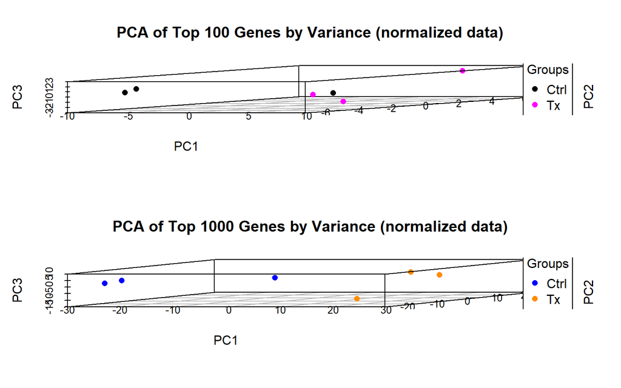

```r
## Visualize PCA results
# Function to create 3D PCA plots
plot_pca_3d <- function(pca_scores, title, colors) {
  # Create the 3D scatter plot
  s3d <- scatterplot3d(
    pca_scores$PC1,
    pca_scores$PC2,
    pca_scores$PC3,
    color = colors[as.factor(pca_scores$Group)],
    pch = 16,
    main = title,
    xlab = "PC1",
    ylab = "PC2",
    zlab = "PC3",
    angle = 40,  # Rotation angle
    box = TRUE
  )

  # Add legend
  legend("right",
         legend = levels(as.factor(pca_scores$Group)),
         col = colors,
         pch = 16,
         title = "Groups")
}

# Set up plotting layout
par(mfrow = c(2, 1), mar = c(4, 4, 4, 4))

# Plot top 100 PCA
plot_pca_3d(
  top100v2_pca$pca_scores,
  "PCA of Top 100 Genes by Variance (normalized data)",
  c("black", "magenta")
)

# Plot top 1000 PCA
plot_pca_3d(
  top1000v2_pca$pca_scores,
  "PCA of Top 1000 Genes by Variance (normalized data)",
  c("blue", "darkorange")
)
```

```r
# Reset plotting parameters
par(mfrow = c(1, 1))
```

# 3 Question 3

## 3.1 Hierchical clustering (default) analysis and repeat with other clustering metrics

The code below are the functions for perform the default hierchical clustering analysis and additional analysis using several clustering metrics. The tested selected clustering metrics are: ward, average, and centroid.

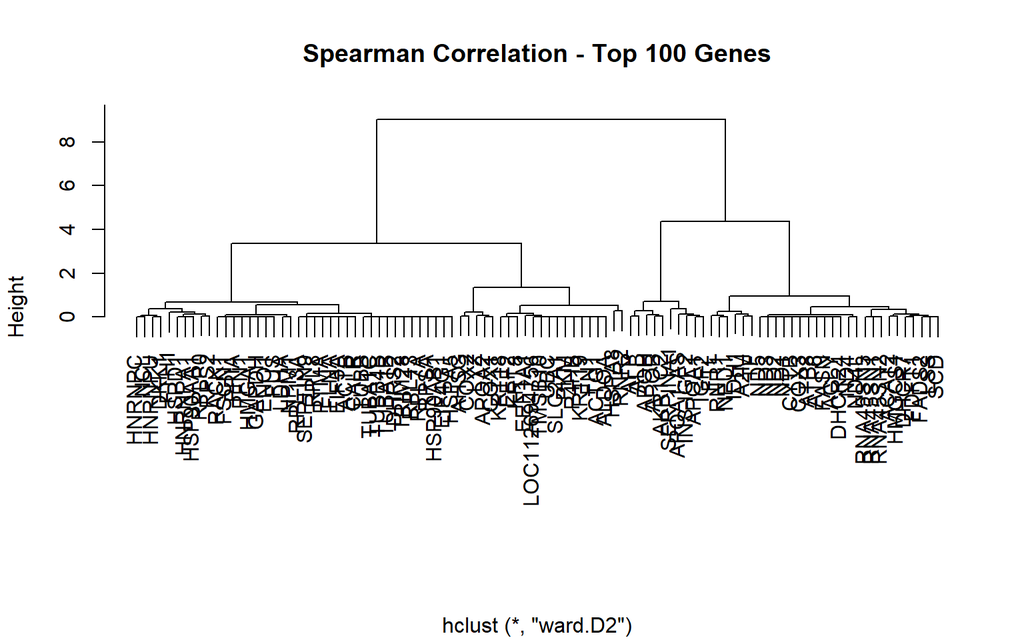

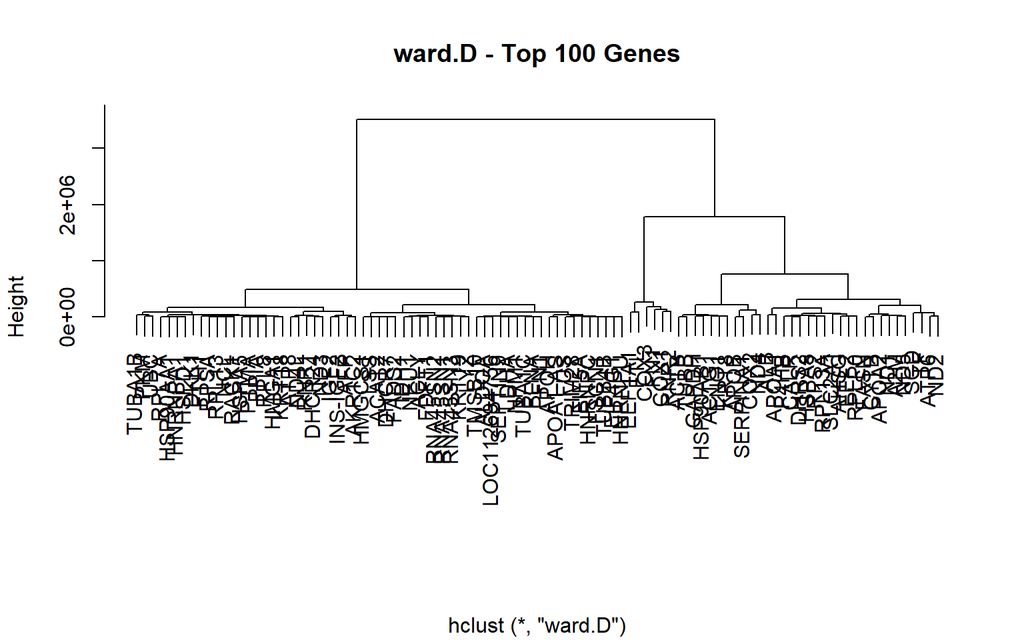

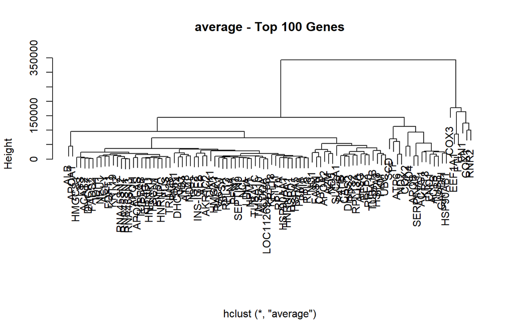

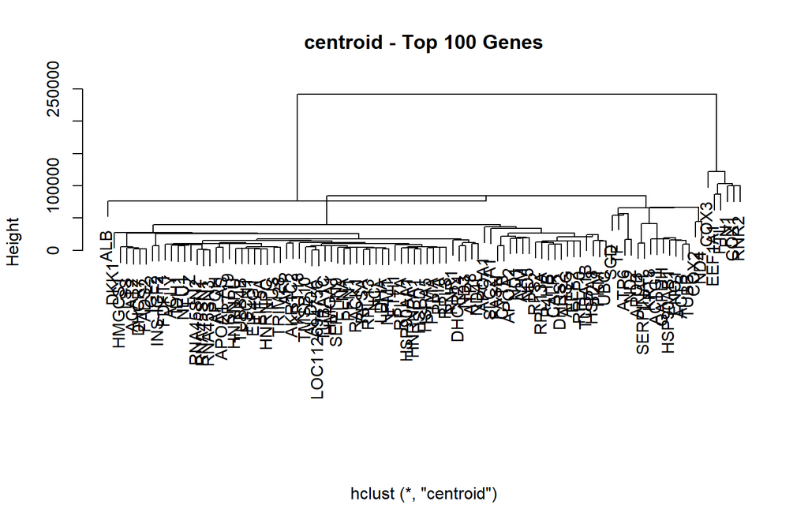

```r
# Clustering methods
cluster_methods <- c("ward.D", "average", "centroid")

# Function to perform clustering
my_cluster <- function(data, method, metric) {
  # Drop group column
  if ("group" %in% colnames(data)) {
    data <- data[, -which(colnames(data) == "group")]
  }
    # Convert data to numeric matrix
  data_matrix <- as.matrix(data)

  if (metric == "spearman") {
    # Correlate genes (columns) for Spearman
    dist_matrix <- as.dist(1 - cor(data_matrix, method = "spearman"))
  } else {
    # Cluster genes (columns) for Euclidean
    dist_matrix <- dist(t(data_matrix), method = metric)
  }
  return(hclust(dist_matrix, method = method))
}

# Function to perform clustering and create plots for each method
perform_clustering <- function(data, gene_set_name) {
  # Create a list to store all plots
  plot_list <- vector("list", length(cluster_methods) + 1)
  names(plot_list) <- c("spearman", cluster_methods)

  # Spearman correlation clustering
  spearman_cluster <- my_cluster(data, "ward.D2", "spearman")
  plot_list[["spearman"]] <- plot(spearman_cluster,
                                 main = paste("Spearman Correlation -", gene_set_name),
                                 xlab = "", ylab = "Height")

  # Euclidean distance-based clustering methods
  for (i in cluster_methods) {
    cluster_result <- my_cluster(data, i, "euclidean")
    plot_list[[i]] <- plot(cluster_result,
                          main = paste(i, "-", gene_set_name),
                          xlab = "", ylab = "Height")
  }
  return(plot_list)
}

# Execute function for top 100
cluster_100 <- perform_clustering(top100_df, "Top 100 Genes")
```

```r
# Set up plotting layout for multiple plots
# Adjust numbers based on how many plots you want to show at once
par(mfrow = c(5, 1))

# Display plots for top 100 genes
for (i in seq_along(cluster_100)) {
  print(cluster_100[[i]])
}
```

The code below will continue the clustering analysis for the top 1000 genes.

```r
# Execute function for top 1000
cluster_1000 <- perform_clustering(top1000_df, "Top 1000 Genes")
```

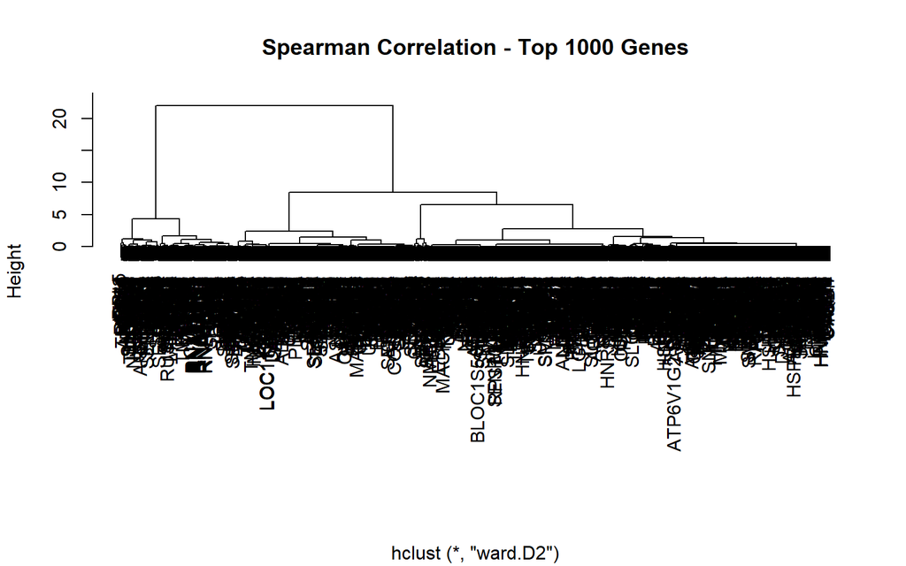

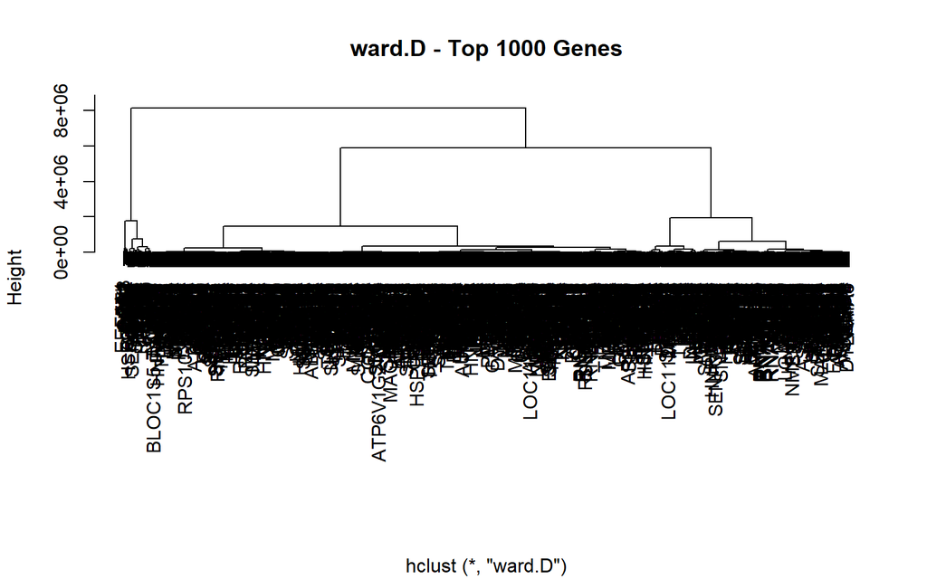

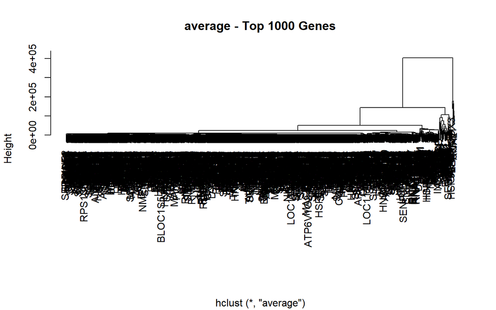

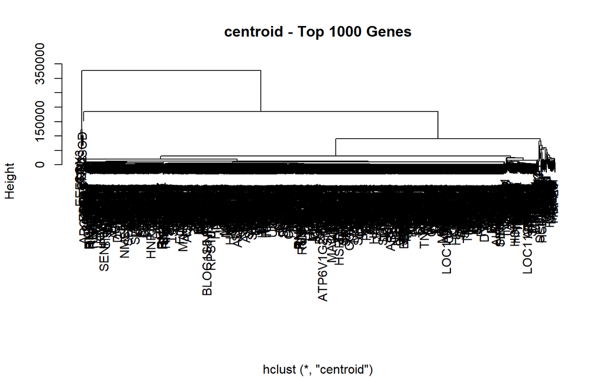

```r
# Set up plotting layout for multiple plots
# Adjust numbers based on how many plots you want to show at once
par(mfrow = c(5, 1), mar = c(4,4,3,1))

# Display plots for top 1000 genes
for (i in seq_along(cluster_1000)) {
  print(cluster_1000[[i]])
}
```

The code below will continue the clustering analysis for all of the genes in the data set.

```r
# Get all genes
all_gene <- GSE252988_2 %>%
  pull(SYMBOL)

# Function to filter & convert data to wide format
filter_convert <- function(selected_genes) {
  GSE252988_4 %>%
    filter(SYMBOL %in% selected_genes) %>%
    pivot_wider(names_from = SYMBOL, values_from = Expression) %>%
    column_to_rownames("Sample_ID")
}

# Execute the function
data_all <- filter_convert(all_gene)

# Execute clustering function for all genes
cluster_all <- perform_clustering(data_all, "All Genes")
```

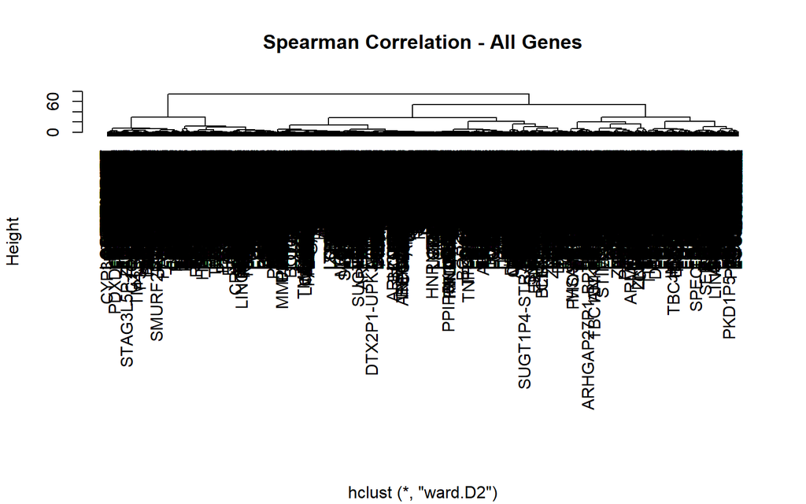

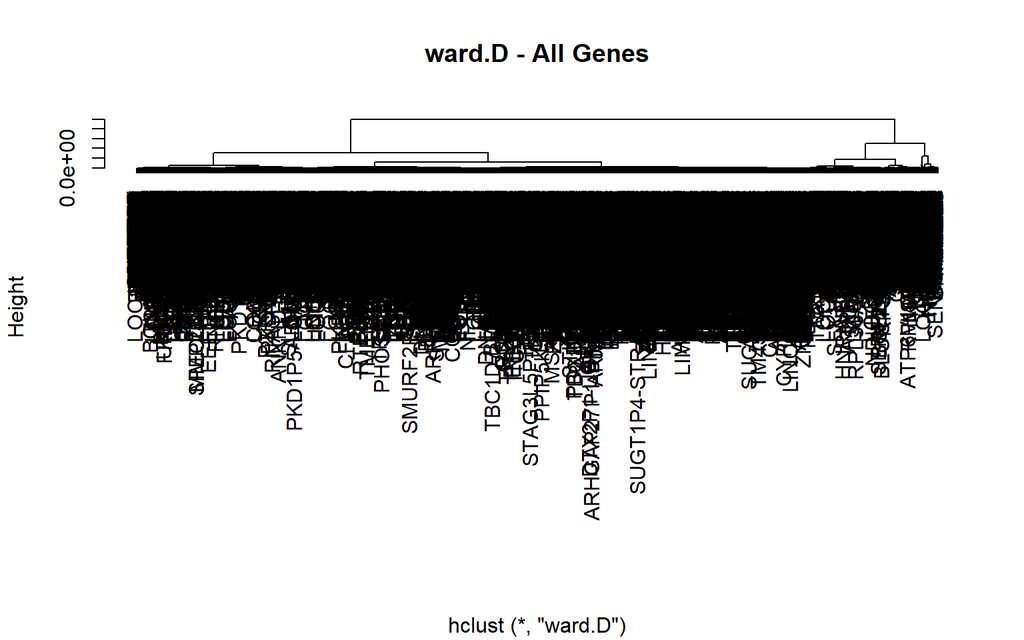

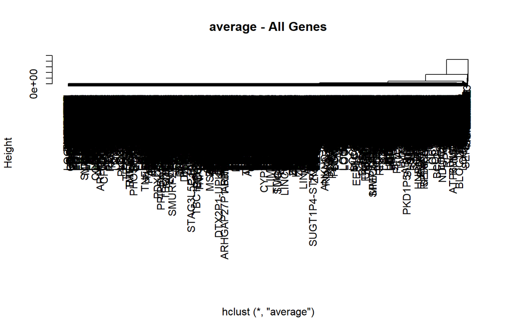

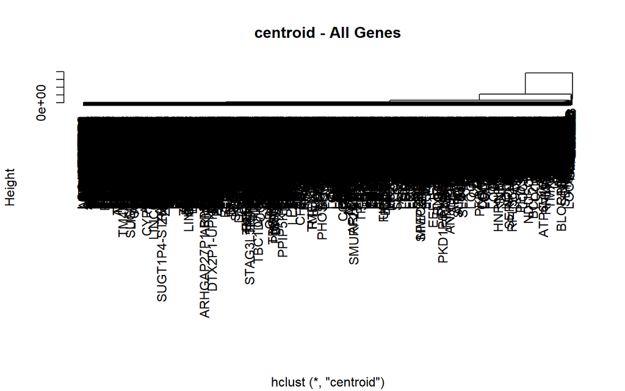

```r
# Set up plotting layout for multiple plots
# Adjust numbers based on how many plots you want to show at once
par(mfrow = c(5, 1), mar = c(4,4,3,1))

# Display plots for top 1000 genes
for (i in seq_along(cluster_all)) {
  print(cluster_all[[i]])
}
```

**Discussion** Since there are several clustering results, the discussion will focus on the comparison of *ward.D* clustering for the top 100 and top 1000 genes. The top 100 genes show distinct high-level clusters, with a large cluster on the left and smaller sub-clusters branching off. Then there are more isolated clusters on the right side. Compared to the top 100 genes, the top 1000 genes plot show a more complex dendrogram with a larger number of high-level clusters. The main difference observed here is that the top 1000 genes plot has a more diverse set of clusters, with a greater number of separate groups branching off at higher levels. This can suggest that increasing the gene set from 100 to 1000 presented more sources of variation. In the top 100 genes the main clusters looks more consolidated, while the top 1000 genes show more distinct separation, which help to show the increased number of genes helped to further differentiate the samples.

Brief description of each clustering method used:  
1. Ward’s method: a hierarchical clustering algorithm that aims to minimize the variance within each cluster. It starts with each point as a separate cluster and then iteratively merges the two clusters that result in the smallest increase in total within-cluster variance. This continues until all points are in the same cluster. Ward’s method is sensitive to the scaling and metric used for measuring the distances between the points. **Ref**: Großwendt, A., Heiko Röglin and Schmidt, M. (2019). Analysis of Ward’s Method. *Society for Industrial and Applied Mathematics eBooks*, pp.2939–2957. doi:https://doi.org/10.1137/1.9781611975482.182.

2. Average-linkage: a hierarchical clustering method that calculates the distance between two clusters as the average distance between all pairs of observations in the clusters. The algorithm then merges the two clusters with the smallest average distance. Average linkage method is one of the several methods of hierarchical clustering that researchers use to detect the patterns in the data. This method tends to produce compact, well-separated clusters and is less sensitive to outliers compared to single linkage. **Ref**: Saraçli, S., Doğan, N. and Doğan, İ., 2013. Comparison of hierarchical cluster analysis methods by cophenetic correlation. *Journal of inequalities and Applications*, 2013, pp.1-8.
3. Centroid-linkage: a hierarchical clustering method that calculates the distance between two clusters by computing the difference between their centroids (the average value of each feature in the cluster). The algorithm then merges the two clusters with the smallest centroid distance. This method is also known as the “UPGMA” (unweighted pair-group method with arithmetic mean) clustering method. Like other hierarchical clustering methods, centroid linkage identifies similarities between observations and groups them into hierarchical structures or clusters.**Ref**: Saraçli, S., Doğan, N. and Doğan, İ., 2013. Comparison of hierarchical cluster analysis methods by cophenetic correlation. *Journal of inequalities and Applications*, 2013, pp.1-8.

# 4 Question 4

### 4.0.1 Identification of most stable dendogram across exponentially increasing slices of the data set sorted by row variance.

The data set used for the code below is the data frame of the top 100 genes (top100_df), in wide format, generated in question #2 (line 248). In the first lines of the code below, the corresponding sample IDs will be added to the data frame since it only contains gene names and gene expression values. Then the variance will be calculated and the genes will be sorted in descending variance order.

```r
# Add sample IDs to the selected data
top100_df2 <- top100_df
top100_df2$Sample_ID <- rownames(top100_df)
top100_df2 <- top100_df2 %>% relocate(Sample_ID, .before = "A2M")

set.seed(42)
# Step 1: Calculate variance for each gene & order by descending variance
gene_var <- apply(top100_df2[, -1], 2, var)
sorted_genes <- top100_df2[, c(1, order(gene_var, decreasing = TRUE) + 1)]
head(gene_var)
```

```
##       A2M     ACAT2      ACLY      ACTB     ACTG1       AFP
##  60617209  20780967  46865750 619376081 401971290  70135656
```

The code below will generate exponentially increasing slices of the data ordered by row variance.

```r
# Step 2: Make exponentially increasing slices
# define slice sizes
total_genes <- ncol(sorted_genes)
base_numbers <- c(2, 4, 16, 256)
slice_sizes <- base_numbers^2
slice_sizes <- slice_sizes[slice_sizes <= total_genes]  # don't let sizes > total genes
slice_sizes <- c(slice_sizes, total_genes - 1) # reduce by 1 for the sample ID column
print(slice_sizes)
```

```
## [1]   4  16 100
```

The code below will perform the clustering analysis by *ward.D* for each slice generated above.

```r
# Step 3: Perform clustering for each slice
# empty list to store clustering results
dendrograms <- list()
# for loop to perform clustering for each slice size
for (size in slice_sizes) {
  # subset data to include only gene values
  subset_data <- t(sorted_genes[, 2:(size + 1)])
  # calculate distance matrix
  dist_matrix <- dist(subset_data)
  # perform hierarchical clustering using "ward.D"
  dendrograms[[as.character(size)]] <- hclust(dist_matrix, method = "ward.D")
}

head(dendrograms)
```

```
## $`4`
##
## Call:
## hclust(d = dist_matrix, method = "ward.D")
##
## Cluster method   : ward.D
## Distance         : euclidean
## Number of objects: 4
##
##
## $`16`
##
## Call:
## hclust(d = dist_matrix, method = "ward.D")
##
## Cluster method   : ward.D
## Distance         : euclidean
## Number of objects: 16
##
##
## $`100`
##
## Call:
## hclust(d = dist_matrix, method = "ward.D")
##
## Cluster method   : ward.D
## Distance         : euclidean
## Number of objects: 100
```

```r
# Step 4: Cut trees at specific height
# empty list to store clustering memberships
membership_counts <- list()
# for loop to cut trees at specific height
for (size in names(dendrograms)) {
  # cut the tree at a specific height
  memberships <- cutree(dendrograms[[size]], k = 3)  # change k to adjust clustering
  # store memberships
  membership_counts[[size]] <- memberships
}
print(membership_counts)
```

```
## $`4`
## COX3  SCD  FN1 COX1
##    1    2    3    1
##
## $`16`
##   COX3    SCD    FN1   COX1    ALB    ND4   ATP6    ND2   KRT8   TUBB   ACTB
##      1      2      1      1      2      2      2      2      3      3      3
##   ENO1   FASN SLC2A1   CYTB     TF
##      3      2      3      2      2
##
## $`100`
##         COX3          SCD          FN1         COX1          ALB          ND4
##            1            2            1            1            2            2
##         ATP6          ND2         KRT8         TUBB         ACTB         ENO1
##            2            2            2            2            2            2
##         FASN       SLC2A1         CYTB           TF          FTL     HSP90AB1
##            2            2            2            2            1            2
##        ACTG1       EEF1A1         COX2        GAPDH          ND1       TUBA1B
##            2            1            2            2            2            3
##        APOA1         DKK1         IGF2        APOA2         RNR2       DHCR24
##            2            3            3            2            1            3
##          ND5     INS-IGF2          PKM          ND3         ATP8         CALR
##            2            3            3            3            3            2
##        KRT18         EEF2        FDFT1         RPS2          AFP        HMGA1
##            3            2            3            2            3            3
##         ND4L          A2M        DHRS2        RPLP0     SERPINA1         PTMA
##            3            2            2            2            2            3
##         APOB         P4HB         ACLY         FLNA        HSPA5          LSS
##            2            2            3            3            3            3
##       TUBA1C         PFN1          LYZ          UBC        HSPA8        DHCR7
##            3            3            3            3            2            3
##       AKR1C2         RPL8         NEU1         RNR1       TMSB10         AHSG
##            3            3            3            3            3            2
##        FSCN1        HSPD1          NCL          FUS        EIF5A        RACK1
##            3            3            3            3            3            3
##        FADS2     APOA1-AS      HNRNPA1       RPL13A        KRT19         FTH1
##            3            3            3            2            3            3
##       TUBB4B        ACAT2     HSP90AA1     RNA45SN2     RNA45SN3     RNA45SN1
##            3            3            3            3            3            3
##         NPM1        RPL13       HMGCS1       HNRNPC        RPL7A         IDH1
##            3            3            3            3            3            3
##        ALDOA LOC112694756         PPIA       TRIM28      SEPTIN9         LDHA
##            3            3            3            3            3            3
##       EIF4G1         APOH         RPSA       HNRNPU
##            3            3            3            3
```

```r
# Compare leaves (samples) and their groupings across slices
# create matrix to store common leaf counts
common_leaf_counts <- matrix(0, nrow = nrow(sorted_genes), ncol = nrow(sorted_genes))
# set the row and column names
rownames(common_leaf_counts) <- colnames(common_leaf_counts) <- sorted_genes$Sample_ID
# for loop to compare leaves (samples)
for (size in names(membership_counts)) {
  current_membership <- membership_counts[[size]]
  # for each pair of samples, check if they're in the same cluster
  for (i in 1:(nrow(sorted_genes) - 1)) {
    for (j in (i + 1):nrow(sorted_genes)) {
      # check if both values exist and are equal
      if (!is.na(current_membership[i]) &&
          !is.na(current_membership[j]) &&
          current_membership[i] == current_membership[j]) {
        common_leaf_counts[i, j] <- common_leaf_counts[i, j] + 1
        common_leaf_counts[j, i] <- common_leaf_counts[j, i] + 1
      }
    }
  }
}

print(common_leaf_counts)
```

```
##            GSM8011934 GSM8011935 GSM8011936 GSM8011937 GSM8011938 GSM8011939
## GSM8011934          0          0          2          3          0          0
## GSM8011935          0          0          0          0          2          2
## GSM8011936          2          0          0          2          0          0
## GSM8011937          3          0          2          0          0          0
## GSM8011938          0          2          0          0          0          2
## GSM8011939          0          2          0          0          2          0
```

Finally, the code below will find the dendrogram with the most stable leaves.

```r
# Find the dendrogram with the most stable leaves
# get the scores
stability_scores <- rowSums(common_leaf_counts)
print(stability_scores)
```

```
## GSM8011934 GSM8011935 GSM8011936 GSM8011937 GSM8011938 GSM8011939
##          5          4          4          5          4          4
```

```r
# get the most stable dendrogram
most_stable <- which.max(stability_scores)
print(most_stable)
```

```
## GSM8011934
##          1
```

The dendrogram and the histograms for each slice are shown below.

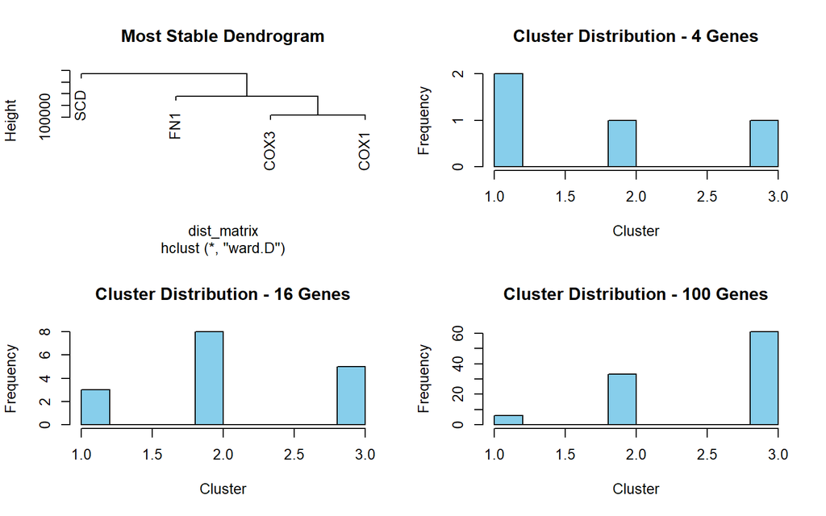

```r
par(mfrow = c(2, 2))
# Plot the most stable dendrogram
most_stable_dendrogram <- dendrograms[[names(dendrograms)[most_stable]]]
plot(most_stable_dendrogram, main = "Most Stable Dendrogram")

# Make histograms for each slice
for (size in names(membership_counts)) {
  hist(membership_counts[[size]], main = paste("Cluster Distribution -", size, "Genes"),
       xlab = "Cluster", col = "skyblue", breaks = 10)
}
```